# Assignment 1 File - Shamit Kotak

### Due February 9, 2024

## Problem Overview

The goal of this homework is hands-on practice with data exploration and cleaning, classification, and model selection. You will:

1. Set up the dataset by doing some preprocessing and EDA
2. Develop logistic regression and tree-based models
3. Interpret and evaluate your models
4. Make predictions in a test dataset

## Introduction

Kickstarter.com is a crowdfunding platform to help fundraisers attract money for projects. Projects are successful if they earn more money than a user-specified goal. If the project is successful, the fundraiser gets to keep all of the money raised; otherwise, they do not get any of the money.

The overall goal of your homework assignments for this class is to accurately predict the target variable “success” in a set of projects for which you do not know the labels. This variable is categorical (binary): YES if the project earned more money than the goal, NO otherwise.

## Data

There are more than 100,000 Kickstarter.com crowdfunding projects in the dataset. These comprise projects with deadlines from 2009-2014. I have provided you with about 60 features for each project. Descriptions of these variables are given in the data dictionary, which I have also provided.

There are six data sets posted on Canvas:

1. ks_training_X.csv: features for the training instances (projects with deadlines before September 2014).
2. ks_training_y.csv: labels for the three target variables for the training instances.
3. ks_test_X.csv: features for the test instances (projects with deadlines in September-December 2014). Your goal is to make predictions for the instances in the test set.

For your convenience, I have randomly subsetted the training data into a smaller set with only 10,000 instances. You can use this subset to explore the data more quickly in R. The files are:

4. small_training_X.csv
5. small_training_y.csv

I’ve made a “fake” test set of y-variable labels (these are all “NO”) to make your coding job easier:

6. ks_test_y_FAKE.csv

## Assignment

Please answer the questions below clearly and concisely, providing tables or plots where applicable. Turn in a well-formatted compiled HTML document using R Markdown, containing clear answers to the questions and R code in the appropriate places.

RUBRIC: To receive a passing score on this assignment, you must do the following:

1. Turn in a well-formatted compiled HTML document using R markdown.
2. Provide clear answers to the questions and the correct R commands as necessary, in the appropriate places. You may answer up to three sub-questions incorrectly (i.e. incorrect R command; missing answer to question) and still receive a P on this assignment (for example, 1(a) counts as one sub-question).
3. The entire document must be clear, concise, and readable.

Note that this assignment is somewhat open-ended and there are many ways to answer these questions. I don’t require that we have exactly the same answers in order for you to receive full credit.

```r
train_X <- read_csv("small_training_X.csv")  #read the datasets in R
train_y <- read_csv("small_training_y.csv")
test_X <- read_csv("ks_test_X.csv")
test_y <- read_csv("ks_test_y_FAKE.csv")
#join the X and y variables
train <- train_X %>%
  left_join(train_y, by = "id") %>%
  mutate(success = as.factor(success),
         original_set = "tr")

test <- test_X %>%
  left_join(test_y, by = "id") %>%
  mutate(success = as.factor(success),
         original_set = "te")

#stack the training and test data

all_data <- rbind(train, test)

names(all_data)                       #variables used in dataset
```

```
##  [1] "id"                  "creator_id"          "name"
##  [4] "creator_name"        "blurb"               "goal"
##  [7] "deadline"            "created_at"          "launched_at"
## [10] "location_slug"       "location_type"       "region"
## [13] "category_parent"     "category_name"       "numfaces_project"
## [16] "numfaces_creator"    "male_project"        "male_creator"
## [19] "female_project"      "female_creator"      "smiling_project"
## [22] "smiling_creator"     "minage_project"      "minage_creator"
## [25] "maxage_project"      "maxage_creator"      "isbwImg1"
## [28] "color_foreground"    "color_background"    "accent_color"
## [31] "captions"            "tag_names"           "isTextPic"
## [34] "isLogoPic"           "isCalendarPic"       "isDiagramPic"
## [37] "isShapePic"          "num_words"           "avg_wordlengths"
## [40] "contains_youtube"    "sentence_counter"    "avgsentencelength"
## [43] "avgsyls"             "grade_level"         "afinn_pos"
## [46] "afinn_neg"           "ADV"                 "NOUN"
## [49] "ADP"                 "PRT"                 "DET"
## [52] "PRON"                "VERB"                "NUM"
## [55] "CONJ"                "ADJ"                 "reward_amounts"
## [58] "reward_descriptions" "success"             "original_set"
```

## 0: Example answer

What is the mean of the goal variable?

**ANSWER: The mean goal of the project listings in this dataset is $15894.20.**

```r
goal_mean <- all_data %>%
  summarise(mean_goal = mean(goal))
```

## 1: Setup

1. Create a new dataset by selecting the following features:
- goal
- region
- category_parent
- numfaces_project
- numfaces_creator
- sentence_counter
- VERB
- success (this is the target variable)
- original_set (this will be used for filtering later)

**ANSWER TO QUESTION 1a HERE:**

```r
#PUT QUESTION 1a CODE HERE
nine_data <- all_data %>%
  select(goal,region,category_parent,numfaces_project,numfaces_creator,sentence_counter,VERB,success,original_set)
```

2. Do some preprocessing on the data:
- convert region, category_parent, and success to factors
- create a new feature called verbs_per_sentence which is the number of verbs per sentence (careful of instances where sentence_counter = 0!)
- create a new feature called high_for_category which is “YES” if the goal is above-average for the project’s category_parent, and “NO” otherwise. Convert this to a factor.

**ANSWER TO QUESTION 1b HERE:**

```r
nine_data <- nine_data %>%
  mutate(region= as.factor(region),category_parent= as.factor(category_parent),success= as.factor(success))

nine_data <- nine_data %>%
  mutate(verbs_per_sentence = ifelse((sentence_counter != 0),VERB/sentence_counter,0))

nine_data <- nine_data %>%
  mutate(high_for_category = as.factor(ifelse((goal>mean(goal)), "YES","NO")))
```

3. Split the data into training, validation, and test. First, separate out the test set by selecting only instances where original_set = te. Separate out the training set by selecting only instances where original_set = tr. Split the training set into 70% train, 30% validation instances. Make sure to drop the original_set variable from all dataframes.

**ANSWER TO QUESTION 1c HERE:**

```r
test_data <- nine_data %>%
  filter(original_set == 'te') %>%
  select(-original_set)

training_set <- nine_data %>%
  filter(original_set == 'tr') %>%
  select(-original_set)

train_insts = sample(nrow(training_set), .7*nrow(training_set))

data_train <- training_set[train_insts,]
data_valid <- training_set[-train_insts,]
```

4. Conduct some preliminary EDA by maing plots using the new training data.
- Make at least one boxplot showing the relationship between success and one of the numeric features.
- Make at least one two-way table showing the relationship between success and one of the categorical features.
- Make at least one scatterplot showing the relationship between any two numeric features.

Record any observations about the relationships you see in the data.

**ANSWER TO QUESTION 1d HERE:**

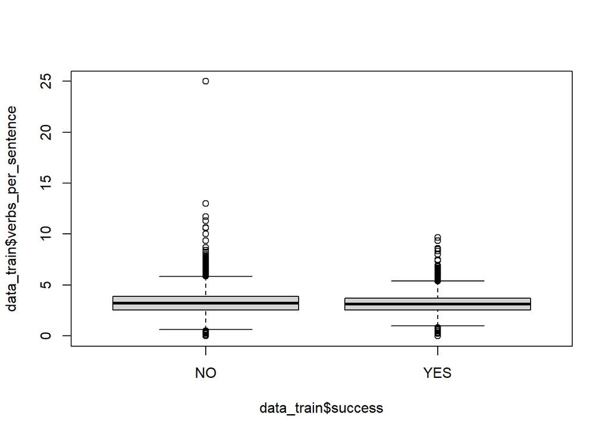

```r
boxplot(data_train$verbs_per_sentence~data_train$success)
```

```r
table(data_train$success,data_train$category_parent)
```

```
##
##        art comics crafts dance design fashion film & video food games
##   NO   359    110     58    30    250     244         1077  285   292
##   YES  366    127     34    94    181     109          858  158   207
##
##       journalism music photography publishing technology theater
##   NO          30   767           9        382        159      54
##   YES         22   259           5        261         84     129
```

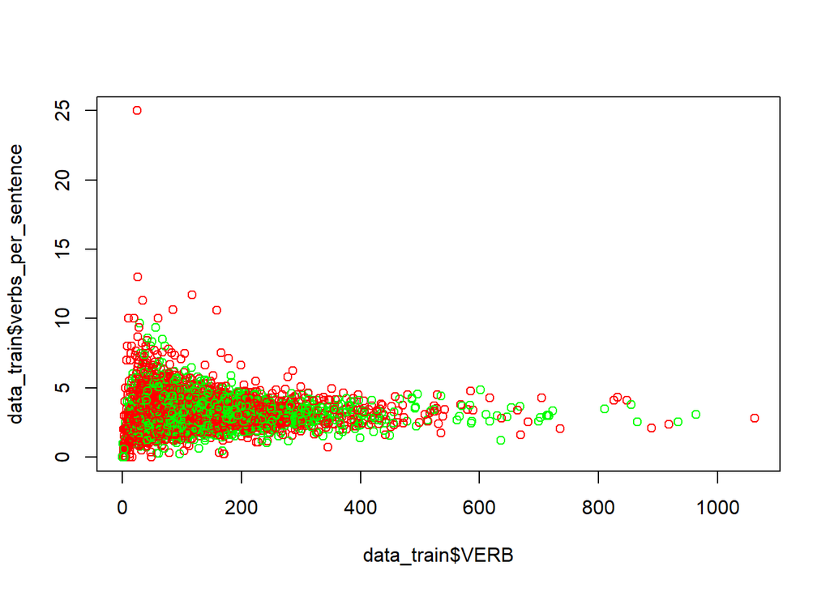

```r
plot(data_train$VERB,
     data_train$verbs_per_sentence,
     col=ifelse(data_train$success=="YES",'green', 'red'))
```

## 2: Logistic Regression

1. Using the training data, train a Logistic Regression model to predict success using the following features:
- goal
- region
- category_parent
- numfaces_project
- numfaces_creator
- sentence_counter
- VERB
- verbs_per_sentence
- high_for_category

Report the AIC for your model.

HINT: you can write the regression formula as “y ~ .” to indicate that all of the other variables in your dataset should be used as features.

**ANSWER TO QUESTION 2a HERE:**

```r
log_mod <- glm(success~., data = data_train, family = "binomial")
log_mod
```

```
##
## Call:  glm(formula = success ~ ., family = "binomial", data = data_train)
##
## Coefficients:
##                 (Intercept)                         goal
##                   3.627e-02                   -1.384e-05
##             regionESCentral                 regionMidAtl
##                  -1.040e-01                    5.305e-01
##              regionMountain                 regionNewEng
##                   1.178e-01                    4.967e-01
##               regionPacific               regionSouthAtl
##                   3.723e-01                   -1.931e-01
##             regionWNCentral              regionWSCentral
##                   8.765e-02                   -2.674e-02
##       category_parentcomics        category_parentcrafts
##                   4.165e-02                   -5.685e-01
##        category_parentdance        category_parentdesign
##                   1.014e+00                   -2.971e-01
##      category_parentfashion  category_parentfilm & video
##                  -8.370e-01                   -1.990e-01
##         category_parentfood         category_parentgames
##                  -4.562e-01                   -5.329e-01
##   category_parentjournalism         category_parentmusic
##                  -3.886e-01                   -1.124e+00
##  category_parentphotography    category_parentpublishing
##                  -9.303e-01                   -4.878e-01
##   category_parenttechnology       category_parenttheater
##                  -5.059e-01                    8.400e-01
##            numfaces_project             numfaces_creator
##                   1.294e-01                   -4.437e-03
##            sentence_counter                         VERB
##                  -2.597e-03                    5.045e-03
##          verbs_per_sentence         high_for_categoryYES
##                  -1.243e-01                   -7.296e-01
##
## Degrees of Freedom: 6999 Total (i.e. Null);  6970 Residual
## Null Deviance:       9493
## Residual Deviance: 8595  AIC: 8655
```

2. What is the coefficient for verbs_per_sentence? Provide a precise (numerical) interpretation of the coefficient.

3. What is the coefficient for high_for_category.YES? Provide a precise (numerical) interpretation of this coefficient.

4. Use the model to make predictions in the validation data and report the accuracy. You can assume a cutoff of 0.5. Make sure your predictions match the data type/format of the target variable in the validation data!

**ANSWER TO QUESTION 2d HERE:**

```r
# Make predictions

log_preds <- predict(log_mod, newdata = data_valid, type = "response")

# Need a score and a cutoff to classify (i.e. map predictions to YES/NO)

log_class <- factor(ifelse(log_preds >= 0.5, "YES", "NO"))

accuracy <- function(actuals, predictions){

  #check if the actuals and predictions match
  #note - they have to be in EXACTLY the same format
  is_correct <- ifelse(actuals == predictions, 1, 0)

  #accuracy is the average # of correct classifications
  accuracy <- mean(is_correct)
  return(accuracy)
}

log_model_accuracy <- accuracy(data_valid$success, log_class)
print(log_model_accuracy)
```

```
## [1] 0.654
```

## 3: Classification Trees

1. Use the following code to create an unpruned tree (replace YOUR_Y_VAR and YOUR_TRAINING_DATA with the appropriate variable names, then uncomment the lines starting with “full_tree…”). How many terminal nodes are in the full tree? Which variable has the highest information gain (leads to the biggest decrease in impurity)? How do you know?

#### Which variable has the highest information gain : The root node has the highest information: in this case is the “goal” variable that is making our first node.

**ANSWER TO QUESTION 2d HERE:**

```r
library(tree)

mycontrol = tree.control(nrow(train), mincut = 5, minsize = 10, mindev = 0.0005)

full_tree=tree(success~., control = mycontrol, data_train)

summary(full_tree)
```

```
##
## Classification tree:
## tree(formula = success ~ ., data = data_train, control = mycontrol)
## Variables actually used in tree construction:
## [1] "goal"               "category_parent"    "VERB"
## [4] "region"             "sentence_counter"   "numfaces_creator"
## [7] "numfaces_project"   "verbs_per_sentence"
## Number of terminal nodes:  232
## Residual mean deviance:  0.9944 = 6730 / 6768
## Misclassification error rate: 0.2623 = 1836 / 7000
```

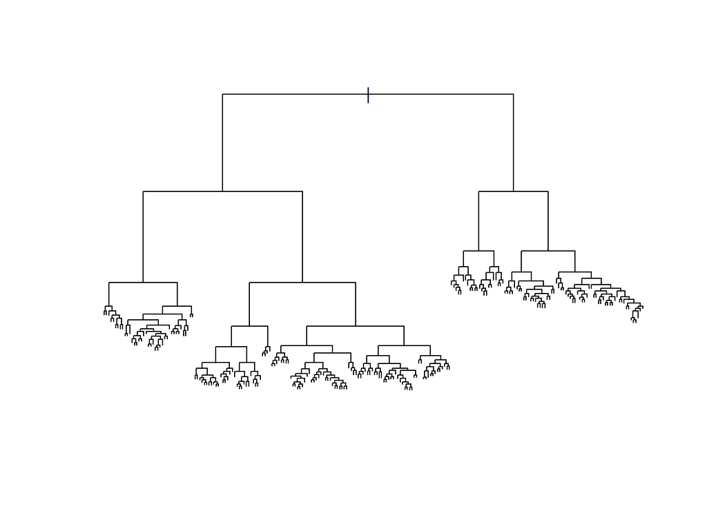

```r
plot(full_tree)
```

```r
full_tree$frame
```

|  | var | n | dev | yval | splits | yprob |
| --- | --- | --- | --- | --- | --- | --- |
| 1 | goal | 7000 | 9493.150114 | NO |  |  |
| 2 | category_parent | 4517 | 6253.297139 | NO |  |  |
| 4 | VERB | 1178 | 1436.815933 | NO |  |  |
| 8 | goal | 348 | 296.966523 | NO |  |  |
| 16 | region | 133 | 144.431208 | NO |  |  |
| 32 |  | 15 | 0.000000 | NO |  |  |
| 33 |  | 118 | 135.906352 | NO |  |  |
| 17 | sentence_counter | 215 | 141.970071 | NO |  |  |
| 34 |  | 41 | 0.000000 | NO |  |  |
| 35 | numfaces_creator | 174 | 132.085698 | NO |  |  |

[output cut: 453 more lines]

```r
total_nodes <- nrow(full_tree$frame)

terminal_nodes <- sum(full_tree$frame$var == "<leaf>")

decision_nodes <- total_nodes - terminal_nodes
```

2. Create pruned trees of size 2, 4, 6, 8, 10, 15, 20, 25, 30, 35, 40, 100, and the size of the full (unpruned) tree. Plot fitting curves consisting of the accuracy in the validation and training sets for each pruned tree (assuming a cutoff of 0.5). Make sure the two sets of points are different colors.

Hint: you might want to change the y-axis of your plot from the default by adding the ylim() argument to plot().

**ANSWER TO QUESTION 3b HERE:**

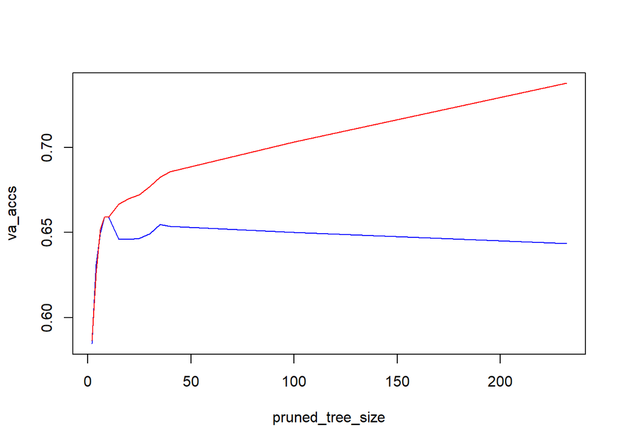

```r
pruned_tree_size <- c(2, 4, 6, 8, 10, 15, 20, 25, 30, 35, 40, 100,terminal_nodes)

num_sizes <- length(pruned_tree_size)
tr_accs = rep(0, num_sizes)
va_accs = rep(0, num_sizes)
#tree_size = rep(0, num_sizes)

predict_classify_evaluate <- function(model_name ,prediction_data){
  tree_preds <- predict(model_name,newdata=prediction_data)

  tree_probs=tree_preds[,2]

  classifications_success <- ifelse(tree_probs > .5, "YES", "NO")
  classifications_success <- ifelse(is.na(classifications_success), "NO", classifications_success)
  table(classifications_success)
  return(accuracy(classifications_success,prediction_data$success))
}

for(k in c(1:num_sizes)){
  inner_size <- pruned_tree_size[k]
  pruned_tree <- prune.tree(full_tree, best = inner_size)
  va_accs[k] <- predict_classify_evaluate(pruned_tree, data_valid)
  tr_accs[k] <- predict_classify_evaluate(pruned_tree, data_train)
  #tree_size[k] <- sum(pruned_tree$frame$var == "<leaf>")

}

ymin <- min(va_accs)
ymax <- max(tr_accs)

plot(pruned_tree_size, va_accs, col = "blue", type = 'l', ylim = c(ymin, ymax))
lines(pruned_tree_size, tr_accs, col = "red")
```

3. Which tree size is the best, and how did you select the best one? Report the validation accuracy of your best tree. Save your best tree model as best_tree_mod (you may have to run prune.tree again).

**ANSWER TO QUESTION 3c HERE:**

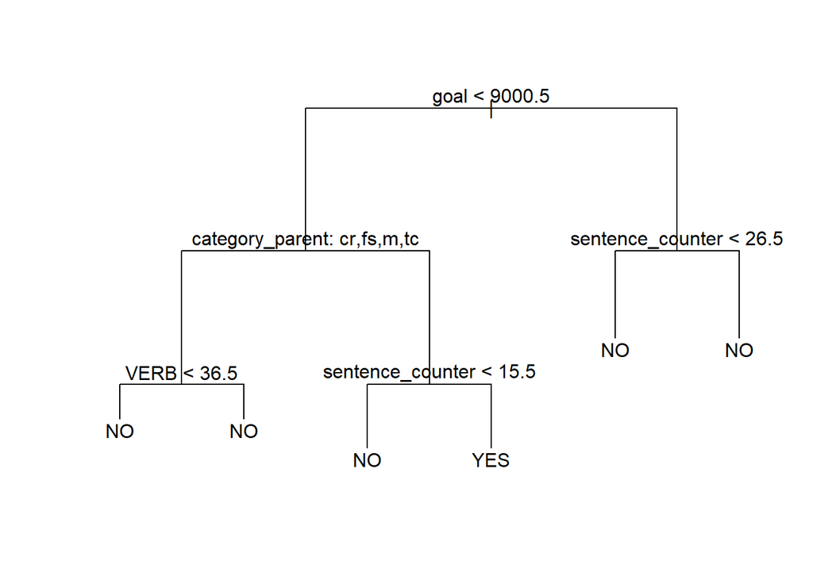

```r
best_tree_mod_size <- 6

inner_size <- best_tree_mod_size
best_tree_mod <- prune.tree(full_tree, best = inner_size)
best_va_accs <- predict_classify_evaluate(best_tree_mod, data_valid)
best_tr_accs <- predict_classify_evaluate(best_tree_mod, data_train)

ymin <- min(best_va_accs)
ymax <- max(best_tr_accs)

plot(best_tree_mod)
text(best_tree_mod,pretty=1)
```

```r
best_va_accs
```

```
## [1] 0.6496667
```

```r
best_tr_accs
```

```
## [1] 0.6518571
```

## 4: Model Selection and Deployment

1. If you were going to pick one of the two models trained above to make accurate predictions in the test data, which would you pick and why?

##### I will prefer Decision tree model as compared to the Logistic model, since in our case both the models provide almost similar accuracy but in many cases decision tree models can provide better accuracy based on larger data sets.

**ANSWER TO QUESTION 4a HERE:**

2. For the model you have selected, make predictions in the test data and do the classification using a cutoff of 0.5. Write them to a .csv file called success_groupXYZ.csv, where you replace XYZ with your team name (or your own last name if you have not joined a team). Your file should have:
- One column, with a header of x
- 11308 predictions, one for each test instance
- Predictions in the format YES/NO

OPTIONAL: submit your predictions to the class contest. If your file does not match these specifications exactly your submission will not be eligible for the leaderboard!

**ANSWER TO QUESTION 4b HERE:**

```r
#hint: to output predictions in the correct format, uncomment the line of code beginning "write.table..."
# replace MY_CLASSIFICATIONS with the name of your variable containing YES/NO predictions
# replace groupXYZ with your group name

tree_preds <- predict(best_tree_mod,newdata=test_data)

  tree_probs=tree_preds[,2]

  classifications_success <- ifelse(tree_probs > .5, "YES", "NO")
  classifications_success <- ifelse(is.na(classifications_success), "NO",   classifications_success)

write.table(classifications_success, "success_group_26.csv", row.names = FALSE)
```

## 5: OPTIONAL ENHANCEMENTS - can be done in teams

If you would like to excel in the contest, you can spend basically infinite time improving your predictions. Your goal should be to predict the values in the test data (for which you do not know the labels) as accurately as possible. Here are some things you can try given just the basics covered in the first few weeks of class. If you have exhausted these possibilities and are wondering where to go next, I’m happy to make more suggestions in office hours.

- Use the full training X and y to train models (Caveats: more training instances will result in slower training time. Also, the model that appears to be “better” with a smaller training set may or may not be better on a larger training set. More later!)
- Select and/or clean more features (Same caveats as above hold. Also, some features have missing values or other issues, so beware!).
- Try a more fine-grained set of possible pruning parameters for the decision tree model.
- Try changing the cutoff for classification.

Include the code you used to generate your enhanced predictions in the code block below.